# Informe Estandarización Perú Escala DINI

Martín Vargas Estrada

2025-01-02 15:54:17.828584

# Introducción

Informe de Exploración Psicométrica de los puntajes de la prueba DINI obtenidas con muestra de Perú, grupos Nivel 3, y Niveles 4-5 años.

# Análisis Descriptivo Nivel 3

Pasaremos a describir y graficar las principales variables demográficas que caracterizan a la muestra:

1. Fecha de Evaluación
2. Edad en meses
3. Cuatrimestre de nacimiento
4. Grupo de Codmod
5. Región Natural
6. Área
7. Nivel Modalidad
8. Gestión
9. Departamento
10. Quintil de Pobreza
11. Incidencia / No Incidencia (VSS)
12. Incidencia Perinatal
13. Inc. Tratamiento Médico
14. Inc. Patología
15. Inc. Negligencia
16. Inc. Mudanza
17. Inc. Consumo
18. Inc. Desempleo
19. Inc. Familiar
20. Inc. Otros
21. Tratamiento Técnico
22. Tratamiento Psicológico
23. Tratamiento Psiquiátrico
24. Tratamiento Pedagógico
25. Tratamiento Psicomotriz
26. Tratamiento Fonoaudiológico
27. Tratamiento Dificultades Diagnosticadas
28. Tratamiento Discapacidad
29. Tratamiento Ninguno
30. Instrucción Previa al Nivel 3

## Fechas de Evaluación

A continuación veamos la distribución según las fechas de evaluación:

Frecuencias de Fecha de Evaluación

| Fecha de Evaluación | N | % | N Acum. | % Acum. |
| --- | --- | --- | --- | --- |
| 04/29/2024 | 270 | 24.88 | 270 | 24.88 |
| 05/20/2024 | 225 | 20.74 | 495 | 45.62 |
| 06/17/2024 | 305 | 28.11 | 800 | 73.73 |
| 08/12/2024 | 285 | 26.27 | 1085 | 100.00 |

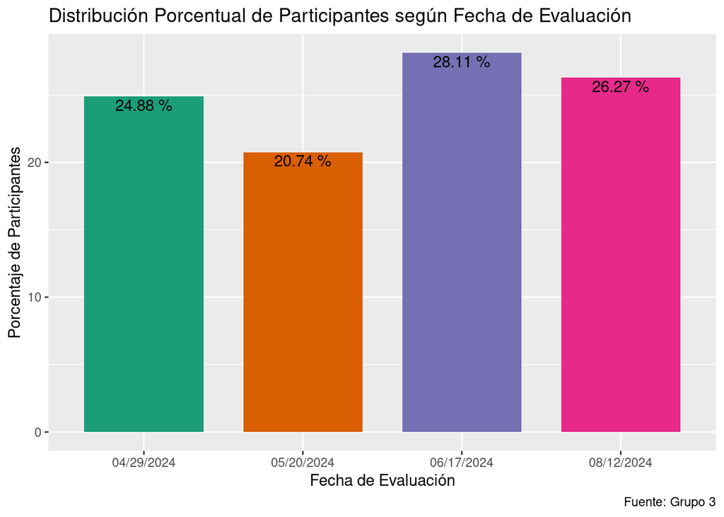

## Edad en Meses

A continuación, la información acerca de la edad en meses del participante

Frecuencias de Edad en Meses

| Edad en Meses | N | % | N Acum. | % Acum. |
| --- | --- | --- | --- | --- |
| 32 | 1 | 0.09 | 1 | 0.09 |
| 33 | 1 | 0.09 | 2 | 0.18 |
| 36 | 5 | 0.46 | 7 | 0.64 |
| 37 | 14 | 1.29 | 21 | 1.93 |
| 38 | 33 | 3.04 | 54 | 4.97 |
| 39 | 51 | 4.70 | 105 | 9.67 |
| 40 | 58 | 5.35 | 163 | 15.02 |
| 41 | 80 | 7.37 | 243 | 22.39 |
| 42 | 79 | 7.28 | 322 | 29.67 |
| 43 | 70 | 6.45 | 392 | 36.12 |
| 44 | 74 | 6.82 | 466 | 42.94 |
| 45 | 78 | 7.19 | 544 | 50.13 |
| 46 | 91 | 8.39 | 635 | 58.52 |
| 47 | 89 | 8.20 | 724 | 66.72 |
| 48 | 97 | 8.94 | 821 | 75.66 |
| 49 | 93 | 8.57 | 914 | 84.23 |
| 50 | 62 | 5.71 | 976 | 89.94 |
| 51 | 31 | 2.86 | 1007 | 92.80 |
| 52 | 20 | 1.84 | 1027 | 94.64 |
| 53 | 7 | 0.65 | 1034 | 95.29 |
| 54 | 5 | 0.46 | 1039 | 95.75 |
| 55 | 10 | 0.92 | 1049 | 96.67 |
| 56 | 3 | 0.28 | 1052 | 96.95 |
| 57 | 4 | 0.37 | 1056 | 97.32 |
| 59 | 5 | 0.46 | 1061 | 97.78 |
| 60 | 3 | 0.28 | 1064 | 98.06 |
| 61 | 5 | 0.46 | 1069 | 98.52 |
| 62 | 6 | 0.55 | 1075 | 99.07 |
| 63 | 7 | 0.65 | 1082 | 99.72 |
| 64 | 3 | 0.28 | 1085 | 100.00 |

| Variable | Mediana | Media | Desviación.Estándar | Número.de.Casos |
| --- | --- | --- | --- | --- |
| Edad en Meses | 45 | 45.51 | 4.88 | 1085 |

A continuación el histograma de la Edad en meses:

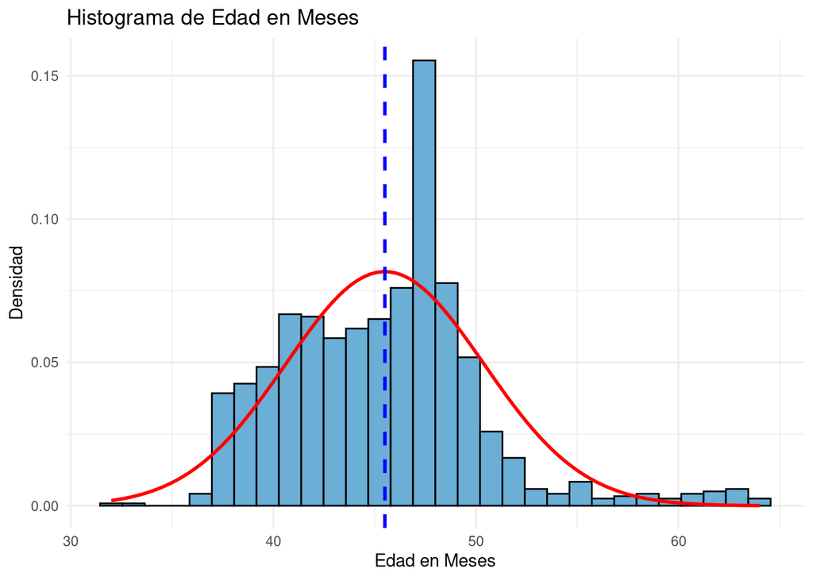

## Cuatrimestre de Nacimiento

Frecuencias de Cuatrimestre

| Cuatrimestre | N | % | N Acum. | % Acum. |
| --- | --- | --- | --- | --- |
| 1 (Ene-Mar) | 222 | 20.46 | 222 | 20.46 |
| 2 (Abr-Jun) | 342 | 31.52 | 564 | 51.98 |
| 3 (Jul-Sep) | 276 | 25.44 | 840 | 77.42 |
| 4 (Oct-Dic) | 245 | 22.58 | 1085 | 100.00 |

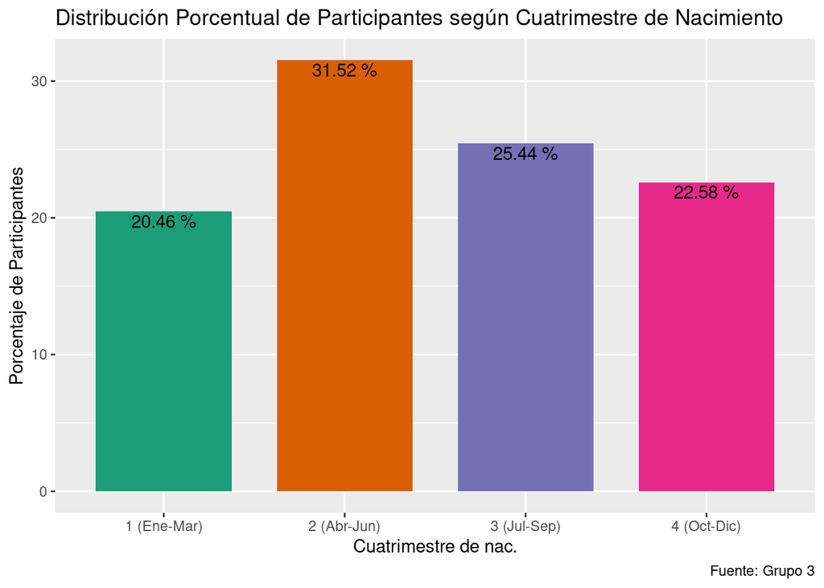

## Código Modular

A continuación, la información acerca del Código Modular

Frecuencias de Código Modular

| Código Modular | N | % | N Acum. | % Acum. |
| --- | --- | --- | --- | --- |
| 0335422 | 75 | 6.91 | 75 | 6.91 |
| 0838441 | 56 | 5.16 | 131 | 12.07 |
| 0403964 | 55 | 5.07 | 186 | 17.14 |
| 0259432 | 52 | 4.79 | 238 | 21.93 |
| 0774372 | 51 | 4.70 | 289 | 26.63 |
| 1504026 | 45 | 4.15 | 334 | 30.78 |
| 1188184 | 44 | 4.06 | 378 | 34.84 |
| 0565598 | 40 | 3.69 | 418 | 38.53 |
| 0259630 | 39 | 3.59 | 457 | 42.12 |
| 0259648 | 39 | 3.59 | 496 | 45.71 |
| 0613646 | 39 | 3.59 | 535 | 49.30 |
| 1321272 | 38 | 3.50 | 573 | 52.80 |
| 0403659 | 33 | 3.04 | 606 | 55.84 |
| 1630029 | 32 | 2.95 | 638 | 58.79 |
| 0542175 | 31 | 2.86 | 669 | 61.65 |
| 1152537 | 30 | 2.76 | 699 | 64.41 |
| 0551192 | 25 | 2.30 | 724 | 66.71 |
| 1055763 | 24 | 2.21 | 748 | 68.92 |
| 0565952 | 23 | 2.12 | 771 | 71.04 |
| 0259770 | 21 | 1.94 | 792 | 72.98 |
| 0404079 | 19 | 1.75 | 811 | 74.73 |
| 0500215 | 18 | 1.66 | 829 | 76.39 |
| 0688838 | 18 | 1.66 | 847 | 78.05 |
| 1137579 | 18 | 1.66 | 865 | 79.71 |
| 0651901 | 15 | 1.38 | 880 | 81.09 |
| 0930842 | 15 | 1.38 | 895 | 82.47 |
| 1491182 | 15 | 1.38 | 910 | 83.85 |
| 1396647 | 14 | 1.29 | 924 | 85.14 |
| 0403675 | 13 | 1.20 | 937 | 86.34 |
| 1516624 | 13 | 1.20 | 950 | 87.54 |
| 0540062 | 11 | 1.01 | 961 | 88.55 |
| 1674837 | 11 | 1.01 | 972 | 89.56 |
| 1746148 | 11 | 1.01 | 983 | 90.57 |
| 1556232 | 10 | 0.92 | 993 | 91.49 |
| 3013380 | 10 | 0.92 | 1003 | 92.41 |
| 1137942 | 9 | 0.83 | 1012 | 93.24 |
| 1559608 | 8 | 0.74 | 1020 | 93.98 |
| 3622240 | 8 | 0.74 | 1028 | 94.72 |
| 1548437 | 7 | 0.65 | 1035 | 95.37 |
| 0772780 | 6 | 0.55 | 1041 | 95.92 |
| 0730275 | 5 | 0.46 | 1046 | 96.38 |
| 1151570 | 5 | 0.46 | 1051 | 96.84 |
| 1262419 | 5 | 0.46 | 1056 | 97.30 |
| 1262773 | 4 | 0.37 | 1060 | 97.67 |
| 1348036 | 4 | 0.37 | 1064 | 98.04 |
| 1396605 | 3 | 0.28 | 1067 | 98.32 |
| 1396720 | 3 | 0.28 | 1070 | 98.60 |
| 1440577 | 3 | 0.28 | 1073 | 98.88 |
| 1714815 | 3 | 0.28 | 1076 | 99.16 |
| 0565606 | 2 | 0.18 | 1078 | 99.34 |
| 0750604 | 2 | 0.18 | 1080 | 99.52 |
| 1439017 | 2 | 0.18 | 1082 | 99.70 |
| 1440627 | 2 | 0.18 | 1084 | 99.88 |
| 0572446 | 1 | 0.09 | 1085 | 99.97 |

## Región Natural

A continuación, la información acerca de la Región Natural

Frecuencias de Regnat

| Regnat | N | % | N Acum. | % Acum. |
| --- | --- | --- | --- | --- |
| Costa | 489 | 45.07 | 489 | 45.07 |
| Sierra | 277 | 25.53 | 766 | 70.60 |
| Selva | 319 | 29.40 | 1085 | 100.00 |

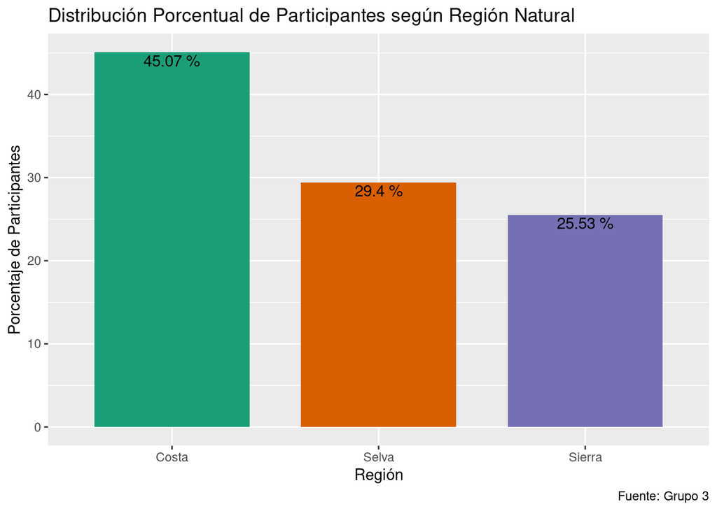

## Área

A continuación, la información acerca del Área

Frecuencias de Area

| Area | N | % | N Acum. | % Acum. |
| --- | --- | --- | --- | --- |
| Urbana | 776 | 71.52 | 776 | 71.52 |
| Rural | 309 | 28.48 | 1085 | 100.00 |

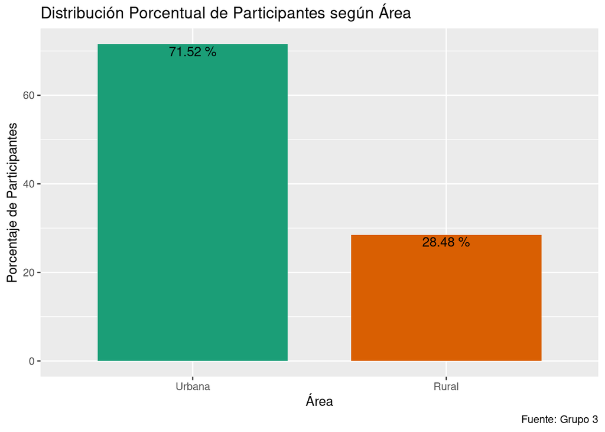

## Nivel Modalidad

A continuación, la información acerca del Nivel Modalidad

Frecuencias de Nivel Modalidad

| Nivel Modalidad | N | % | N Acum. | % Acum. |
| --- | --- | --- | --- | --- |
| Inicial - Jardín | 893 | 82.30 | 893 | 82.30 |
| Inicial - Cuna-jardín | 184 | 16.96 | 1077 | 99.26 |
| Inicial - Programa no escolarizado | 8 | 0.74 | 1085 | 100.00 |

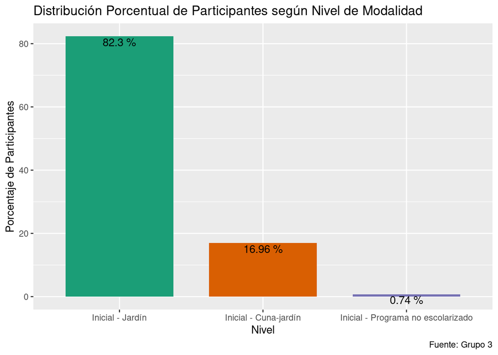

## Gestión

A continuación, la información acerca de la Gestión (Pública o Privada) de la institución edicativa.

Frecuencias de Gestión

| Gestión | N | % | N Acum. | % Acum. |
| --- | --- | --- | --- | --- |
| Pública | 967 | 89.12 | 967 | 89.12 |
| Privada | 118 | 10.88 | 1085 | 100.00 |

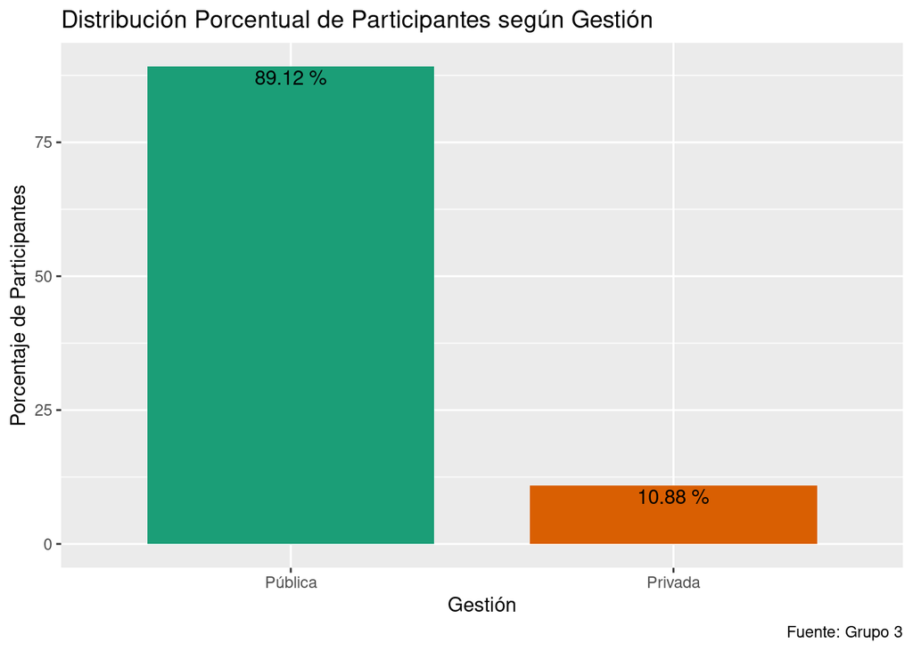

## Departamento

A continuación, la información acerca del Departamento en donde vive el participante.

Frecuencias de Departamento

| Departamento | N | % | N Acum. | % Acum. |
| --- | --- | --- | --- | --- |
| Piura | 305 | 28.11 | 305 | 28.11 |
| Lima Metropolitana | 285 | 26.27 | 590 | 54.38 |
| Cusco | 270 | 24.88 | 860 | 79.26 |
| Loreto | 225 | 20.74 | 1085 | 100.00 |

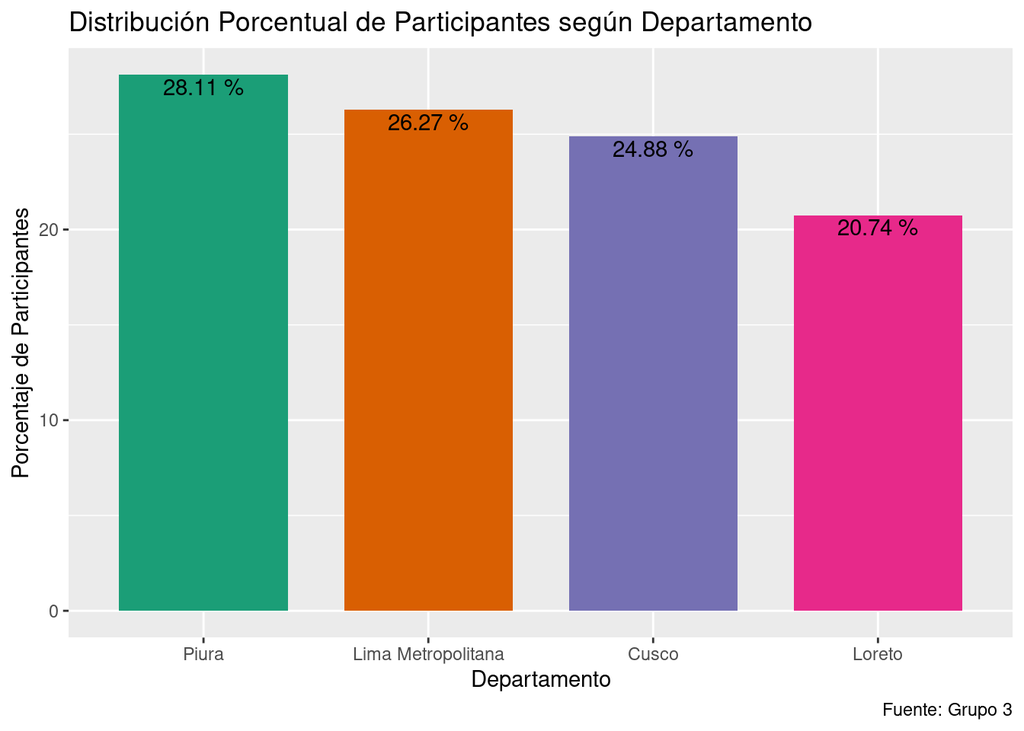

## Quintil de Pobreza

Frecuencias de Quintil

| Quintil | N | % | N Acum. | % Acum. |
| --- | --- | --- | --- | --- |
| 1 | 137 | 12.63 | 137 | 12.63 |
| 2 | 90 | 8.29 | 227 | 20.92 |
| 3 | 198 | 18.25 | 425 | 39.17 |
| 4 | 392 | 36.13 | 817 | 75.30 |
| 5 | 268 | 24.70 | 1085 | 100.00 |

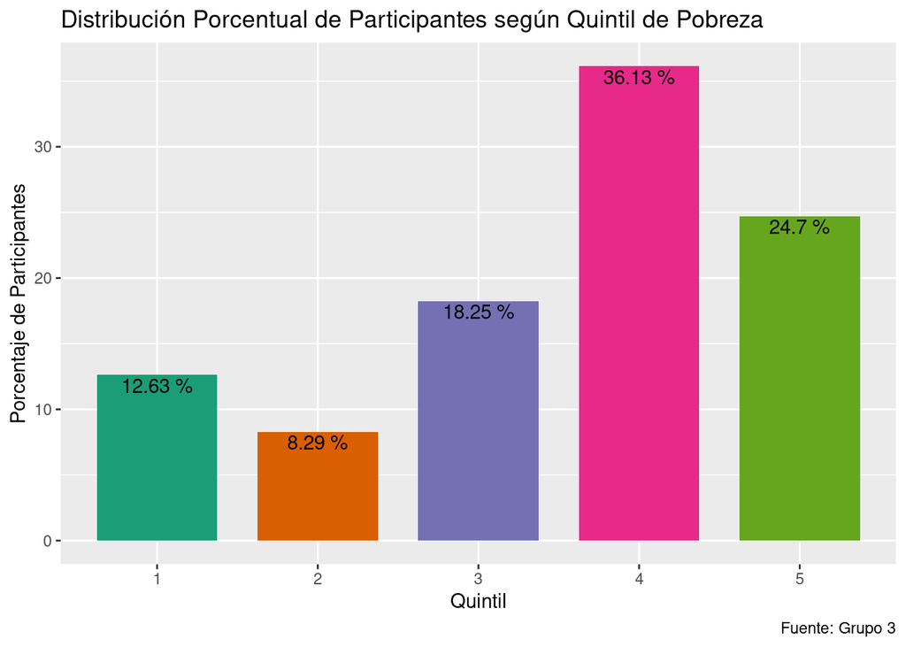

## Incidencia / No Incidencia (VSS)

A continuación, la información acerca de la Incidencia / No Incidencia.

Frecuencias de Incidencia

| Incidencia | N | % | N Acum. | % Acum. |
| --- | --- | --- | --- | --- |
| No | 976 | 89.95 | 976 | 89.95 |
| Sí | 109 | 10.05 | 1085 | 100.00 |

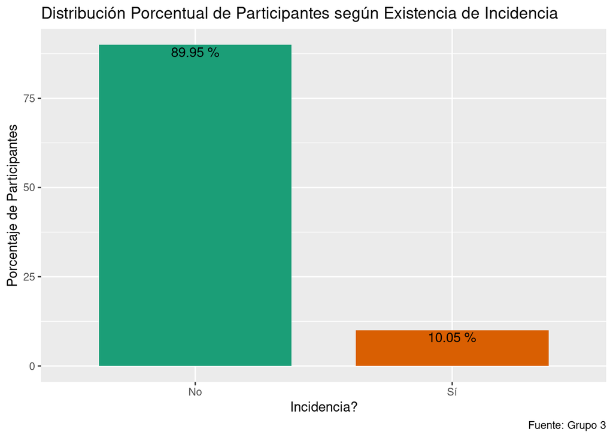

## Incidencia Perinatal (VSSdesper)

A continuación, la información acerca de la Incidencia Perinatal.

Frecuencias de Incidencia Perinatal

| Incidencia Perinatal | N | % | N Acum. | % Acum. |
| --- | --- | --- | --- | --- |
| No | 1067 | 98.34 | 1067 | 98.34 |
| Sí | 18 | 1.66 | 1085 | 100.00 |

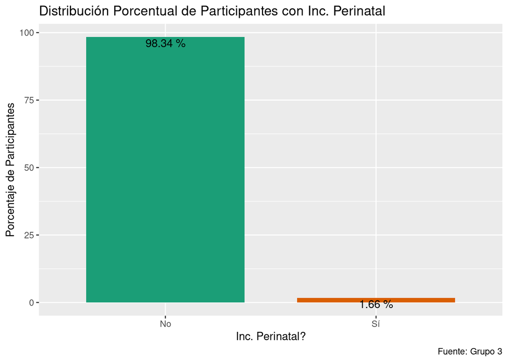

## Incidencia Tratamiento Médico (VSSttomed)

A continuación, la información acerca de la Incidencia por Tratamiento Médico.

Frecuencias de Tto. Médico

| Tto. Médico | N | % | N Acum. | % Acum. |
| --- | --- | --- | --- | --- |
| No | 1067 | 98.34 | 1067 | 98.34 |
| Sí | 18 | 1.66 | 1085 | 100.00 |

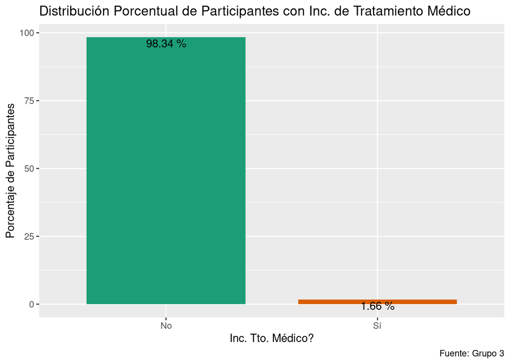

## Incidencia por Patología (VSSpatolo)

A continuación, la información acerca de la Incidencia por Patología.

Frecuencias de Patología

| Patología | N | % | N Acum. | % Acum. |
| --- | --- | --- | --- | --- |
| No | 1078 | 99.35 | 1078 | 99.35 |
| Sí | 7 | 0.65 | 1085 | 100.00 |

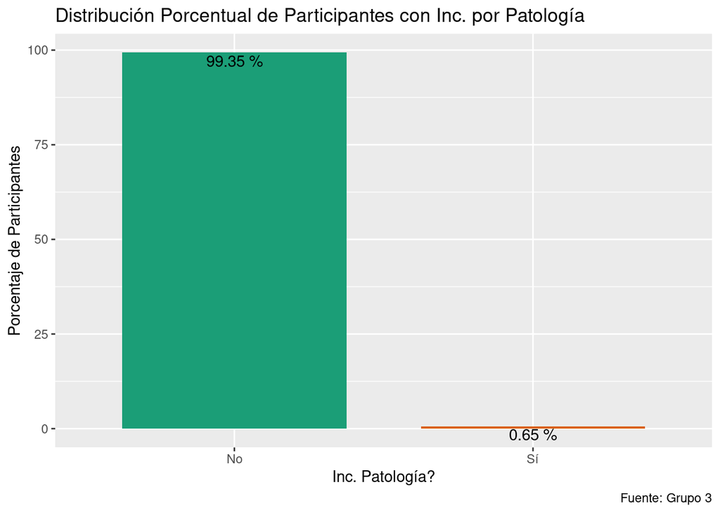

## Incidencia por Negligencia (VSSnegl)

A continuación, la información acerca de la Incidencia por Negligencia

Frecuencias de Negligencia

| Negligencia | N | % | N Acum. | % Acum. |
| --- | --- | --- | --- | --- |
| No | 1080 | 99.54 | 1080 | 99.54 |
| Sí | 5 | 0.46 | 1085 | 100.00 |

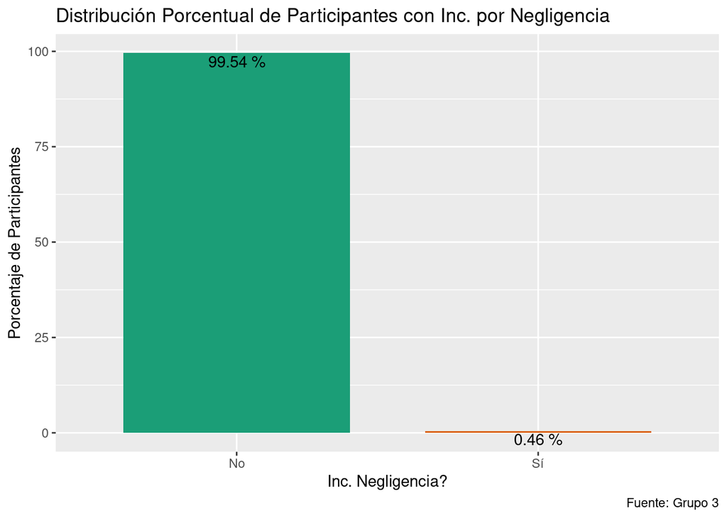

## Incidencia por Mudanza (VSSmud)

A continuación, la información acerca de la Incidencia por Mudanza

Frecuencias de Inc. Mudanza

| Inc. Mudanza | N | % | N Acum. | % Acum. |
| --- | --- | --- | --- | --- |
| No | 1055 | 97.24 | 1055 | 97.24 |
| Sí | 30 | 2.76 | 1085 | 100.00 |

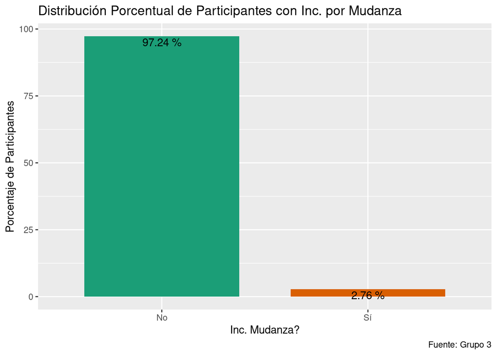

## Incidencia por Consumo (VSSconsus)

A continuación, la información acerca de la Incidencia por Consumo:

Frecuencias de Inc. Consumo

| Inc. Consumo | N | % | N Acum. | % Acum. |
| --- | --- | --- | --- | --- |
| No | 1080 | 99.54 | 1080 | 99.54 |
| Sí | 5 | 0.46 | 1085 | 100.00 |

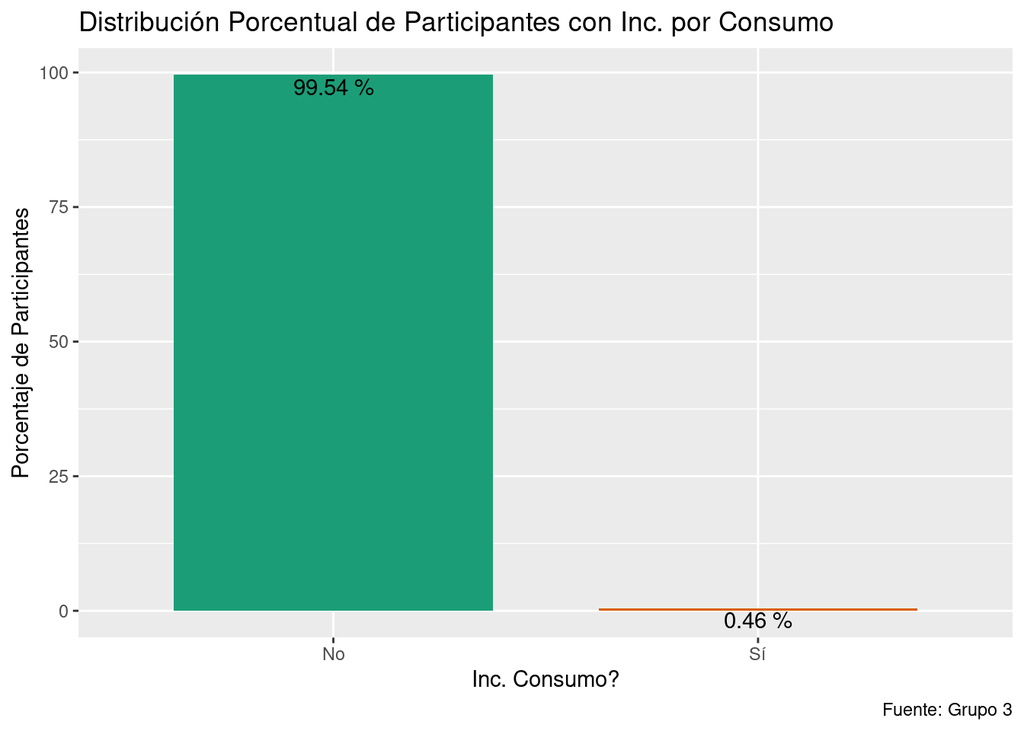

## Incidencia por Desempleo (VSSdesemp)

A continuación, la información acerca de la Incidencia por Desempleo:

Frecuencias de Inc. por Desempleo

| Inc. por Desempleo | N | % | N Acum. | % Acum. |
| --- | --- | --- | --- | --- |
| No | 1061 | 97.79 | 1061 | 97.79 |
| Sí | 24 | 2.21 | 1085 | 100.00 |

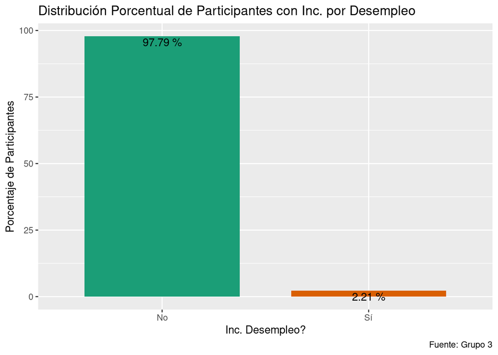

## Incidencia Familiar (VSSfamprilib)

A continuación, la información acerca de la Incidencia Familiar:

Frecuencias de Inc. Familiar

| Inc. Familiar | N | % | N Acum. | % Acum. |
| --- | --- | --- | --- | --- |
| No | 1084 | 99.91 | 1084 | 99.91 |
| Sí | 1 | 0.09 | 1085 | 100.00 |

[figure not shown]

## Incidencia Otros (VSSotro)

A continuación, la información acerca de la Incidencia Otros:

Frecuencias de Inc. Otros

| Inc. Otros | N | % | N Acum. | % Acum. |
| --- | --- | --- | --- | --- |
| No | 1033 | 95.21 | 1033 | 95.21 |
| Sí | 52 | 4.79 | 1085 | 100.00 |

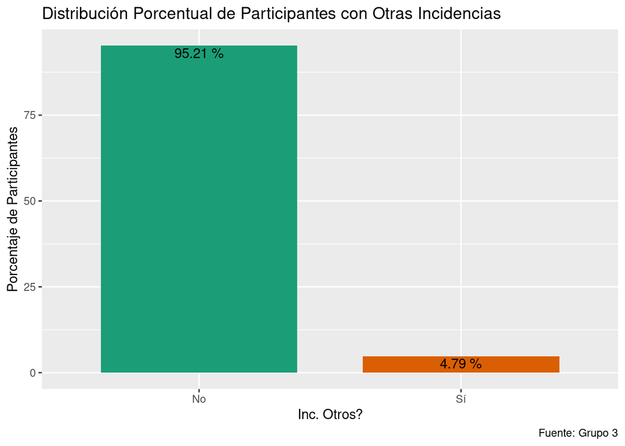

## Tratamiento Técnico (RTT)

A continuación, la información acerca de Tratamiento Técnico:

Frecuencias de Tto. Técnico

| Tto. Técnico | N | % | N Acum. | % Acum. |
| --- | --- | --- | --- | --- |
| No | 1056 | 97.33 | 1056 | 97.33 |
| Sí | 29 | 2.67 | 1085 | 100.00 |

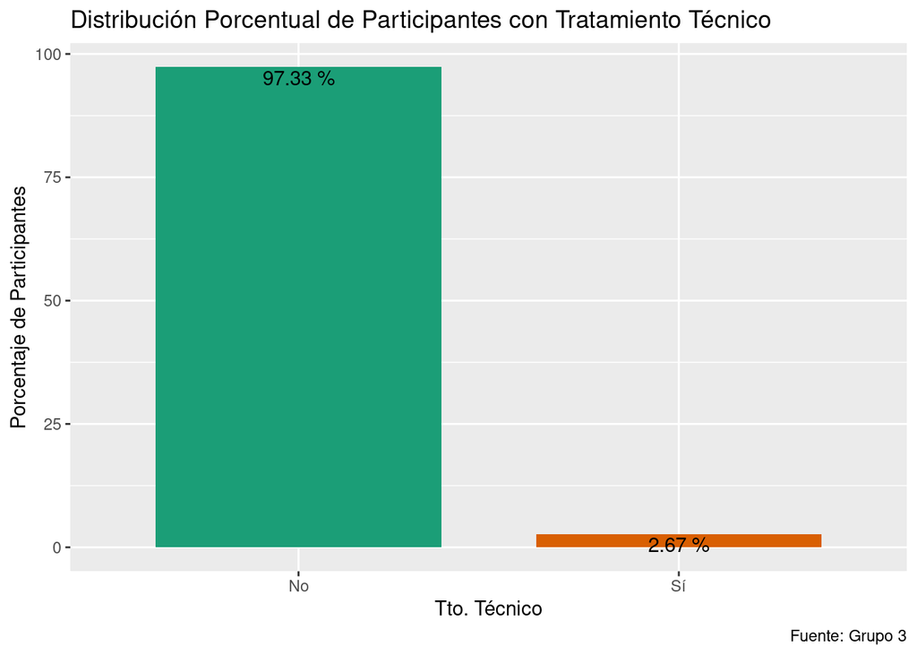

## Tratamiento Psicológico (RTTasipsi)

A continuación, la información acerca de Tratamiento Psicológico:

Frecuencias de Tto. Psicológico

| Tto. Psicológico | N | % | N Acum. | % Acum. |
| --- | --- | --- | --- | --- |
| No | 1061 | 97.79 | 1061 | 97.79 |
| Sí | 24 | 2.21 | 1085 | 100.00 |

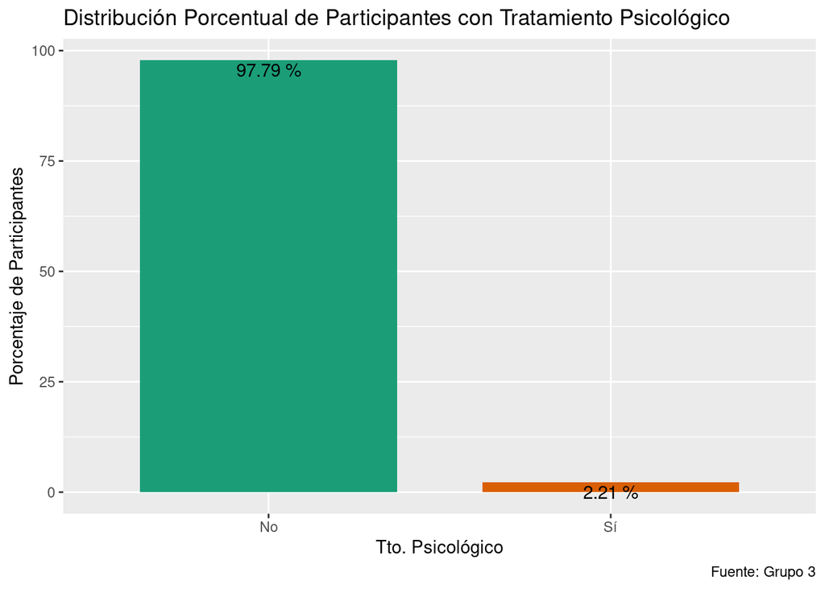

## Tratamiento Psiquiátrico (RTTasipsiq)

A continuación, la información acerca de Tratamiento Psiquiátrico:

Frecuencias de Tto. Psiquiátrico

| Tto. Psiquiátrico | N | % | N Acum. | % Acum. |
| --- | --- | --- | --- | --- |
| No | 1082 | 99.72 | 1082 | 99.72 |
| Sí | 3 | 0.28 | 1085 | 100.00 |

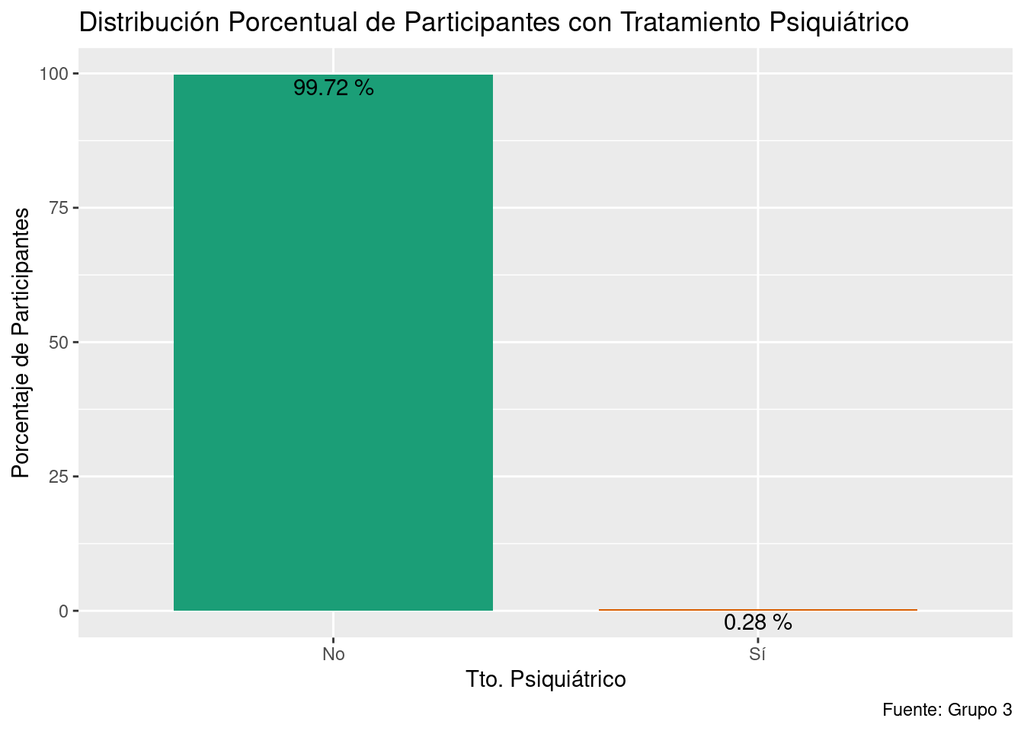

## Tratamiento Pedagógico (RTTasiped)

A continuación, la información acerca de Tratamiento Pedagógico:

Frecuencias de Tto. Pedagógico

| Tto. Pedagógico | N | % | N Acum. | % Acum. |
| --- | --- | --- | --- | --- |
| No | 1065 | 98.16 | 1065 | 98.16 |
| Sí | 20 | 1.84 | 1085 | 100.00 |

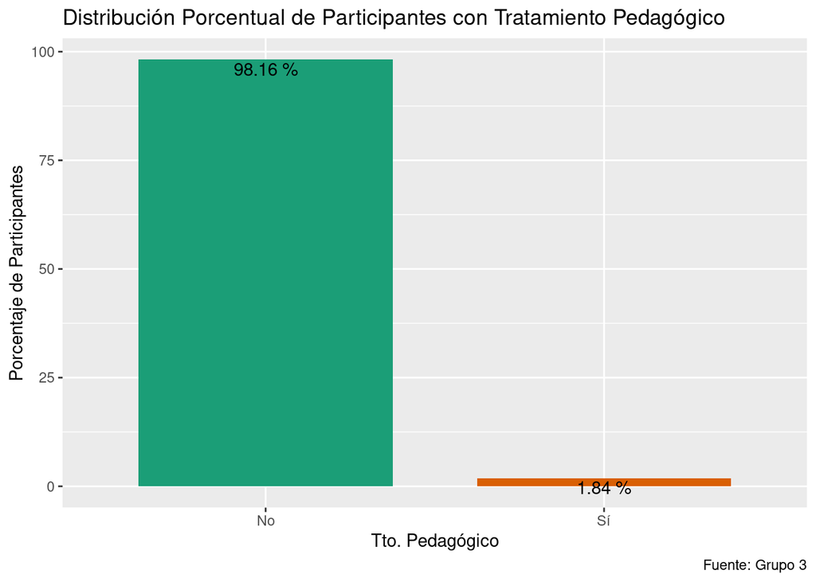

## Tratamiento Psicomotriz (RTTasipsim)

A continuación, la información acerca de Tratamiento Psicomotriz:

Frecuencias de Tto. Psicomotriz

| Tto. Psicomotriz | N | % | N Acum. | % Acum. |
| --- | --- | --- | --- | --- |
| No | 1063 | 97.97 | 1063 | 97.97 |
| Sí | 22 | 2.03 | 1085 | 100.00 |

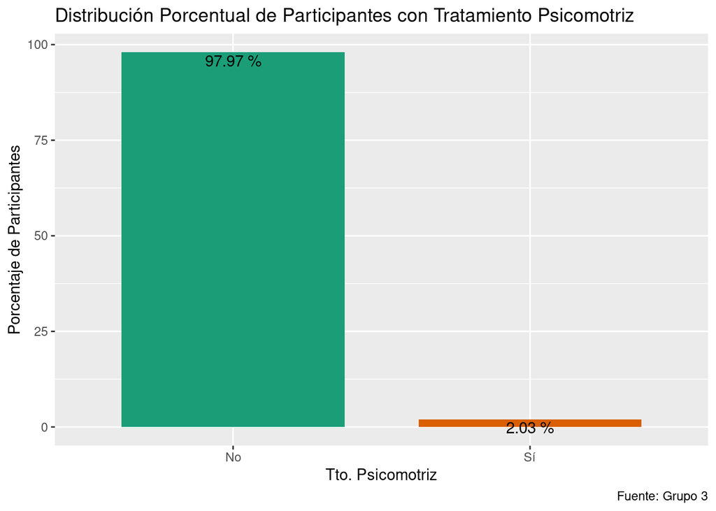

## Tratamiento Fonoaudiológico (RTTasifon)

A continuación, la información acerca de Tratamiento Fonoaudiológico:

Frecuencias de Tto. Fonoaudiológico

| Tto. Fonoaudiológico | N | % | N Acum. | % Acum. |
| --- | --- | --- | --- | --- |
| No | 1069 | 98.53 | 1069 | 98.53 |
| Sí | 16 | 1.47 | 1085 | 100.00 |

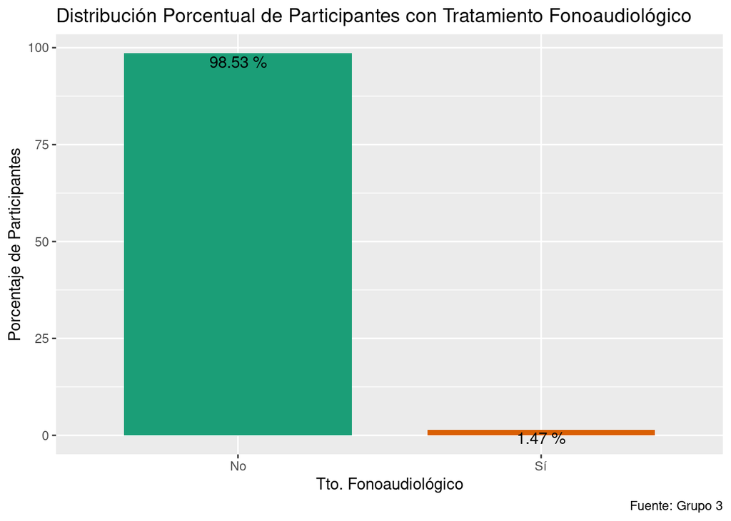

## Tratamiento por Dificultades Diagnosticadas (RTTdifdiag)

A continuación, la información acerca de Tratamiento por Dificultades Diagnosticadas:

Frecuencias de Tto. por Dif. Diag.

| Tto. por Dif. Diag. | N | % | N Acum. | % Acum. |
| --- | --- | --- | --- | --- |
| No | 1084 | 99.91 | 1084 | 99.91 |
| Sí | 1 | 0.09 | 1085 | 100.00 |

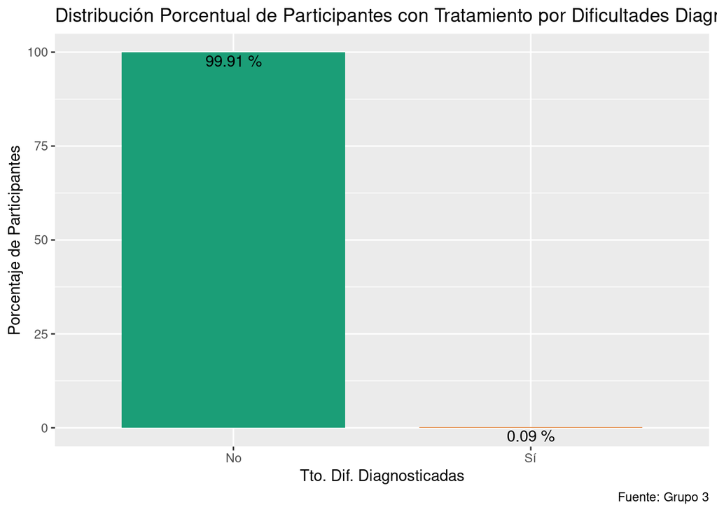

## Tratamiento por Discapacidad (RTTdisc)

A continuación, la información acerca de Tratamiento por Discapacidad:

Frecuencias de Tto. por Discapacidad

| Tto. por Discapacidad | N | % | N Acum. | % Acum. |
| --- | --- | --- | --- | --- |
| No | 1082 | 99.72 | 1082 | 99.72 |
| Sí | 3 | 0.28 | 1085 | 100.00 |

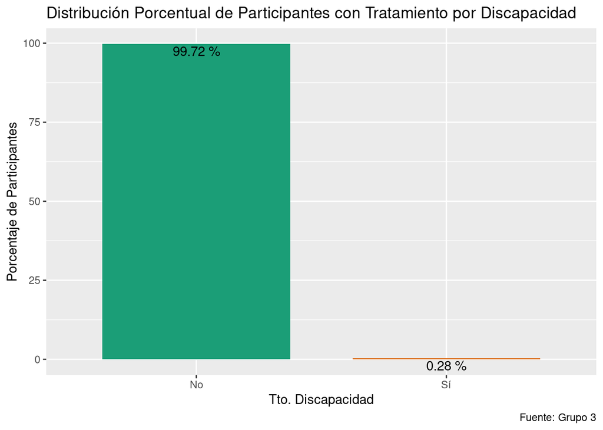

## Ningún Tratamiento (RTTnin)

A continuación, la información acerca de los participantes que no reciben ningún tratamiento:

Frecuencias de Ningún Tto.

| Ningún Tto. | N | % | N Acum. | % Acum. |
| --- | --- | --- | --- | --- |
| Sí | 1012 | 93.27 | 1012 | 93.27 |
| No | 73 | 6.73 | 1085 | 100.00 |

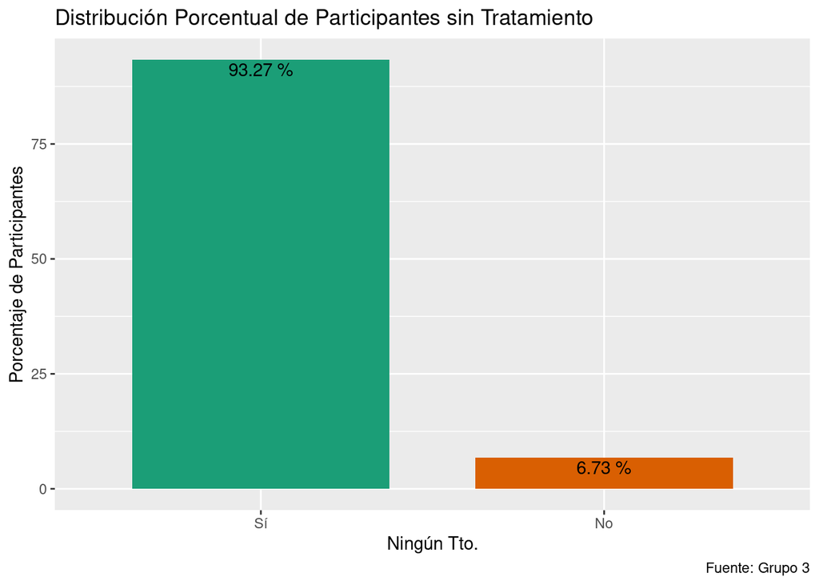

## Instrucción Previa al Nivel 3 (Insant3a)

Frecuencias de Instruc. Previa

| Instruc. Previa | N | % | N Acum. | % Acum. |
| --- | --- | --- | --- | --- |
| No | 723 | 66.64 | 723 | 66.64 |
| Sí | 287 | 26.45 | 1010 | 93.09 |
| NS/NR | 75 | 6.91 | 1085 | 100.00 |

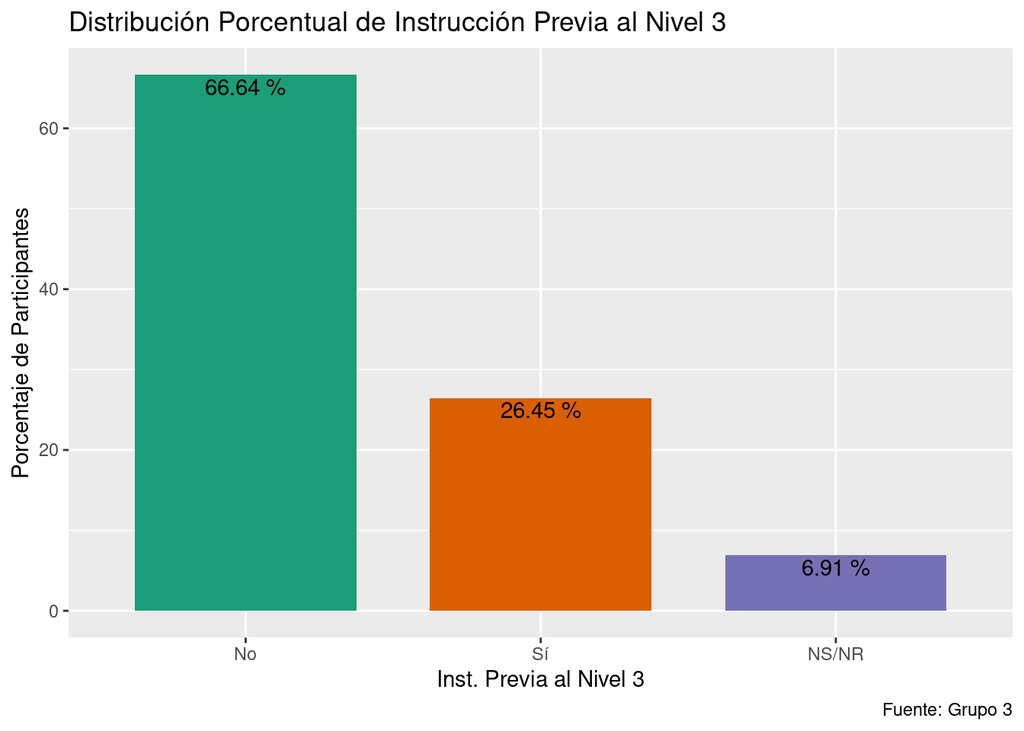

# Análisis Escalar Nivel 3

En esta sección pasaremos a analizar la escala DINI en su aplicación al grupo de Nivel 3.

## Estructura de Subescalas

1. La subescala “C” está compuesta por los ítems C1 a C23 (23 ítems)
2. La subescala “M” está compuesta por los ítems M1 a M08 (08 ítems)
3. La subescala “S” está compuesta por los ítems S1 a S13 (13 ítems)
4. La subescala “D” está compuesta por los ítems D1 a D06 (06 ítems)

Iniciaremos con el análisis de normalidad de las subescalas.

## Análisis de Normalidad Escala DINI

### Estadísticos Descriptivos

| Variable | Número.de.Casos | Mediana | Media | Desviación.Estándar |
| --- | --- | --- | --- | --- |
| CLEN_sum | 1021 | 21 | 22.69 | 8.47 |
| CMAT_sum | 1021 | 15 | 16.71 | 6.78 |
| CDES_sum | 1021 | 15 | 15.59 | 5.68 |
| CFEX_sum | 1021 | 18 | 18.48 | 5.84 |
| SHAS_sum | 1021 | 18 | 18.19 | 5.34 |
| SINT_sum | 1021 | 9 | 9.38 | 3.63 |
| SEXT_sum | 1021 | 6 | 7.42 | 3.76 |
| C_sum | 1021 | 70 | 73.46 | 24.21 |
| M_sum | 1021 | 27 | 27.32 | 7.51 |
| D_sum | 1021 | 25 | 25.55 | 5.94 |